# report

```python
import pandas as pd
import datetime
import matplotlib.pyplot as plt
import seaborn as sns
import copy
import numpy as np
```

```python
dataFrame = pd.read_csv("marketing_campaign.csv")
dataFrame.info()
```

```
<class 'pandas.core.frame.DataFrame'>
RangeIndex: 2240 entries, 0 to 2239
Data columns (total 20 columns):
 #   Column             Non-Null Count  Dtype
---  ------             --------------  -----
 0   Unnamed: 0         2240 non-null   int64
 1   ID                 2240 non-null   int64
 2   Year_Birth         2240 non-null   int64
 3   Education          2240 non-null   object
 4   Marital_Status     2240 non-null   object
 5   Income             2017 non-null   float64
 6   Kidhome            2240 non-null   int64
 7   Teenhome           2240 non-null   int64
 8   Dt_Customer        2240 non-null   object
 9   Recency            2240 non-null   int64
 10  MntCoffee          2035 non-null   float64
 11  MntFruits          2240 non-null   int64
 12  MntMeatProducts    2240 non-null   int64
 13  MntFishProducts    2240 non-null   int64
 14  MntSweetProducts   2240 non-null   int64
 15  MntGoldProds       2227 non-null   float64
 16  NumWebVisitsMonth  2040 non-null   float64
 17  Complain           2240 non-null   int64
 18  NumPurchases       2240 non-null   int64
 19  UsedCampaignOffer  2240 non-null   int64
dtypes: float64(4), int64(13), object(3)
memory usage: 350.1+ KB
```

```python
dataFrame.describe()
```

|  | Unnamed: 0 | ID | Year_Birth | Income | Kidhome | Teenhome | Recency | MntCoffee | MntFruits | MntMeatProducts | MntFishProducts | MntSweetProducts | MntGoldProds | NumWebVisitsMonth | Complain | NumPurchases | UsedCampaignOffer |
| --- | --- | --- | --- | --- | --- | --- | --- | --- | --- | --- | --- | --- | --- | --- | --- | --- | --- |
| count | 2240.000000 | 2240.000000 | 2240.000000 | 2017.000000 | 2240.000000 | 2240.000000 | 2240.000000 | 2035.000000 | 2240.000000 | 2240.000000 | 2240.000000 | 2240.000000 | 2227.000000 | 2040.000000 | 2240.000000 | 2240.000000 | 2240.000000 |
| mean | 1119.500000 | 5592.159821 | 1968.805804 | 52297.080317 | 0.437946 | 0.506250 | 49.109375 | 304.239312 | 26.302232 | 166.950000 | 37.525446 | 27.062946 | 43.847777 | 5.326961 | 0.009375 | 14.862054 | 0.271875 |
| std | 646.776623 | 3246.662198 | 11.984069 | 25543.108215 | 0.563666 | 0.544538 | 28.962453 | 337.515534 | 39.773434 | 225.715373 | 54.628979 | 41.280498 | 51.897098 | 2.439349 | 0.096391 | 7.677173 | 0.445025 |
| min | 0.000000 | 0.000000 | 1893.000000 | 2447.000000 | -5.000000 | 0.000000 | 0.000000 | 0.000000 | 0.000000 | 0.000000 | 0.000000 | 0.000000 | 0.000000 | 0.000000 | 0.000000 | 0.000000 | 0.000000 |
| 25% | 559.750000 | 2828.250000 | 1959.000000 | 35340.000000 | 0.000000 | 0.000000 | 24.000000 | 23.000000 | 1.000000 | 16.000000 | 3.000000 | 1.000000 | 9.000000 | 3.000000 | 0.000000 | 8.000000 | 0.000000 |
| 50% | 1119.500000 | 5458.500000 | 1970.000000 | 51369.000000 | 0.000000 | 0.000000 | 49.000000 | 177.000000 | 8.000000 | 67.000000 | 12.000000 | 8.000000 | 24.000000 | 6.000000 | 0.000000 | 15.000000 | 0.000000 |
| 75% | 1679.250000 | 8427.750000 | 1977.000000 | 68316.000000 | 1.000000 | 1.000000 | 74.000000 | 505.000000 | 33.000000 | 232.000000 | 50.000000 | 33.000000 | 56.000000 | 7.000000 | 0.000000 | 21.000000 | 1.000000 |
| max | 2239.000000 | 11191.000000 | 1996.000000 | 666666.000000 | 2.000000 | 2.000000 | 99.000000 | 1493.000000 | 199.000000 | 1725.000000 | 259.000000 | 263.000000 | 362.000000 | 20.000000 | 1.000000 | 44.000000 | 1.000000 |

```python
numOfRows = dataFrame.shape[0]
nonNullList = dataFrame.notnull().sum()[1:]
nullList = {}
for name,num in nonNullList.items():
    numOfNull = numOfRows - num
    nullList[name] = {"NumOfNulls" : int(numOfNull) , "Ratio" : numOfNull/numOfRows}
nullData = pd.DataFrame(nullList).T
nullData['NumOfNulls'] = nullData['NumOfNulls'].astype(int)
display(nullData)
```

|  | NumOfNulls | Ratio |
| --- | --- | --- |
| ID | 0 | 0.000000 |
| Year_Birth | 0 | 0.000000 |
| Education | 0 | 0.000000 |
| Marital_Status | 0 | 0.000000 |
| Income | 223 | 0.099554 |
| Kidhome | 0 | 0.000000 |
| Teenhome | 0 | 0.000000 |
| Dt_Customer | 0 | 0.000000 |
| Recency | 0 | 0.000000 |
| MntCoffee | 205 | 0.091518 |
| MntFruits | 0 | 0.000000 |
| MntMeatProducts | 0 | 0.000000 |
| MntFishProducts | 0 | 0.000000 |
| MntSweetProducts | 0 | 0.000000 |
| MntGoldProds | 13 | 0.005804 |
| NumWebVisitsMonth | 200 | 0.089286 |
| Complain | 0 | 0.000000 |
| NumPurchases | 0 | 0.000000 |
| UsedCampaignOffer | 0 | 0.000000 |

```python
educationVals = dataFrame["Education"].unique()
dataFrame["Education"] = dataFrame["Education"].replace('Basic',1)
dataFrame["Education"] = dataFrame["Education"].replace('2n Cycle',2)
dataFrame["Education"] = dataFrame["Education"].replace('Graduation',3)
dataFrame["Education"] = dataFrame["Education"].replace('Master',4)
dataFrame["Education"] = dataFrame["Education"].replace('PhD',5)

display(dataFrame)
```

|  | Unnamed: 0 | ID | Year_Birth | Education | Marital_Status | Income | Kidhome | Teenhome | Dt_Customer | Recency | MntCoffee | MntFruits | MntMeatProducts | MntFishProducts | MntSweetProducts | MntGoldProds | NumWebVisitsMonth | Complain | NumPurchases | UsedCampaignOffer |
| --- | --- | --- | --- | --- | --- | --- | --- | --- | --- | --- | --- | --- | --- | --- | --- | --- | --- | --- | --- | --- |
| 0 | 0 | 5524 | 1957 | 3 | Single | 58138.0 | 0 | 0 | 04-09-2012 | 58 | 635.0 | 88 | 546 | 172 | 88 | 88.0 | NaN | 0 | 25 | 1 |
| 1 | 1 | 2174 | 1954 | 3 | Single | 46344.0 | 1 | 1 | 08-03-2014 | 38 | NaN | 1 | 6 | 2 | 1 | 6.0 | 5.0 | 0 | 6 | 0 |
| 2 | 2 | 4141 | 1965 | 3 | Together | 71613.0 | 0 | 0 | 21-08-2013 | 26 | NaN | 49 | 127 | 111 | 21 | 42.0 | NaN | 0 | 21 | 0 |
| 3 | 3 | 6182 | 1984 | 3 | Together | 26646.0 | 1 | 0 | 10-02-2014 | 26 | 11.0 | 4 | 20 | 10 | 3 | 5.0 | 6.0 | 0 | 8 | 0 |
| 4 | 4 | 5324 | 1981 | 5 | Married | 58293.0 | 1 | 0 | 19-01-2014 | 94 | 173.0 | 43 | 118 | 46 | 27 | 15.0 | 5.0 | 0 | 19 | 0 |
| ... | ... | ... | ... | ... | ... | ... | ... | ... | ... | ... | ... | ... | ... | ... | ... | ... | ... | ... | ... | ... |
| 2235 | 2235 | 10870 | 1967 | 3 | Married | 61223.0 | 0 | 1 | 13-06-2013 | 46 | 709.0 | 43 | 182 | 42 | 118 | 247.0 | 5.0 | 0 | 18 | 0 |
| 2236 | 2236 | 4001 | 1946 | 5 | Together | 64014.0 | 2 | 1 | 10-06-2014 | 56 | 406.0 | 0 | 30 | 0 | 0 | 8.0 | 7.0 | 0 | 22 | 1 |
| 2237 | 2237 | 7270 | 1981 | 3 | Divorced | 56981.0 | 0 | 0 | 25-01-2014 | 91 | 908.0 | 48 | 217 | 32 | 12 | 24.0 | 6.0 | 0 | 19 | 1 |
| 2238 | 2238 | 8235 | 1956 | 4 | Together | 69245.0 | 0 | 1 | 24-01-2014 | 8 | 428.0 | 30 | 214 | 80 | 30 | 61.0 | NaN | 0 | 23 | 0 |
| 2239 | 2239 | 9405 | 1954 | 5 | Married | 52869.0 | 1 | 1 | 15-10-2012 | 40 | 84.0 | 3 | 61 | 2 | 1 | 21.0 | 7.0 | 0 | 11 | 1 |

2240 rows × 20 columns

```python
MaritalstatusVals = dataFrame["Marital_Status"].unique()
print(MaritalstatusVals)
```

```
['Single' 'Together' 'Married' 'Divorced' 'Widow' 'Alone' 'Absurd' 'YOLO']
```

```python
dataFrame = dataFrame[(dataFrame['Marital_Status'] !='Absurd') & (dataFrame['Marital_Status'] != 'YOLO')]
couple = ['Together','Married']
for val in MaritalstatusVals:
    if val in couple:
        dataFrame["Marital_Status"] = dataFrame["Marital_Status"].replace(val,1)
    else:
        dataFrame["Marital_Status"] = dataFrame["Marital_Status"].replace(val,0)

display(dataFrame)
```

|  | Unnamed: 0 | ID | Year_Birth | Education | Marital_Status | Income | Kidhome | Teenhome | Dt_Customer | Recency | MntCoffee | MntFruits | MntMeatProducts | MntFishProducts | MntSweetProducts | MntGoldProds | NumWebVisitsMonth | Complain | NumPurchases | UsedCampaignOffer |
| --- | --- | --- | --- | --- | --- | --- | --- | --- | --- | --- | --- | --- | --- | --- | --- | --- | --- | --- | --- | --- |
| 0 | 0 | 5524 | 1957 | 3 | 0 | 58138.0 | 0 | 0 | 04-09-2012 | 58 | 635.0 | 88 | 546 | 172 | 88 | 88.0 | NaN | 0 | 25 | 1 |
| 1 | 1 | 2174 | 1954 | 3 | 0 | 46344.0 | 1 | 1 | 08-03-2014 | 38 | NaN | 1 | 6 | 2 | 1 | 6.0 | 5.0 | 0 | 6 | 0 |
| 2 | 2 | 4141 | 1965 | 3 | 1 | 71613.0 | 0 | 0 | 21-08-2013 | 26 | NaN | 49 | 127 | 111 | 21 | 42.0 | NaN | 0 | 21 | 0 |
| 3 | 3 | 6182 | 1984 | 3 | 1 | 26646.0 | 1 | 0 | 10-02-2014 | 26 | 11.0 | 4 | 20 | 10 | 3 | 5.0 | 6.0 | 0 | 8 | 0 |
| 4 | 4 | 5324 | 1981 | 5 | 1 | 58293.0 | 1 | 0 | 19-01-2014 | 94 | 173.0 | 43 | 118 | 46 | 27 | 15.0 | 5.0 | 0 | 19 | 0 |
| ... | ... | ... | ... | ... | ... | ... | ... | ... | ... | ... | ... | ... | ... | ... | ... | ... | ... | ... | ... | ... |
| 2235 | 2235 | 10870 | 1967 | 3 | 1 | 61223.0 | 0 | 1 | 13-06-2013 | 46 | 709.0 | 43 | 182 | 42 | 118 | 247.0 | 5.0 | 0 | 18 | 0 |
| 2236 | 2236 | 4001 | 1946 | 5 | 1 | 64014.0 | 2 | 1 | 10-06-2014 | 56 | 406.0 | 0 | 30 | 0 | 0 | 8.0 | 7.0 | 0 | 22 | 1 |
| 2237 | 2237 | 7270 | 1981 | 3 | 0 | 56981.0 | 0 | 0 | 25-01-2014 | 91 | 908.0 | 48 | 217 | 32 | 12 | 24.0 | 6.0 | 0 | 19 | 1 |
| 2238 | 2238 | 8235 | 1956 | 4 | 1 | 69245.0 | 0 | 1 | 24-01-2014 | 8 | 428.0 | 30 | 214 | 80 | 30 | 61.0 | NaN | 0 | 23 | 0 |
| 2239 | 2239 | 9405 | 1954 | 5 | 1 | 52869.0 | 1 | 1 | 15-10-2012 | 40 | 84.0 | 3 | 61 | 2 | 1 | 21.0 | 7.0 | 0 | 11 | 1 |

2236 rows × 20 columns

```python
def DateToDay(input_date):
    date = datetime.datetime.strptime(input_date, '%d-%m-%Y')
    days = (datetime.date(date.year, date.month,date.day) - datetime.date(1, 1, 1)).days
    return days
```

```python
dataFrame["Dt_Customer"] = dataFrame["Dt_Customer"].apply(DateToDay)
```

```python
dataFrame.drop('Unnamed: 0',axis=1,inplace=True)
corrData = dataFrame.corr()
```

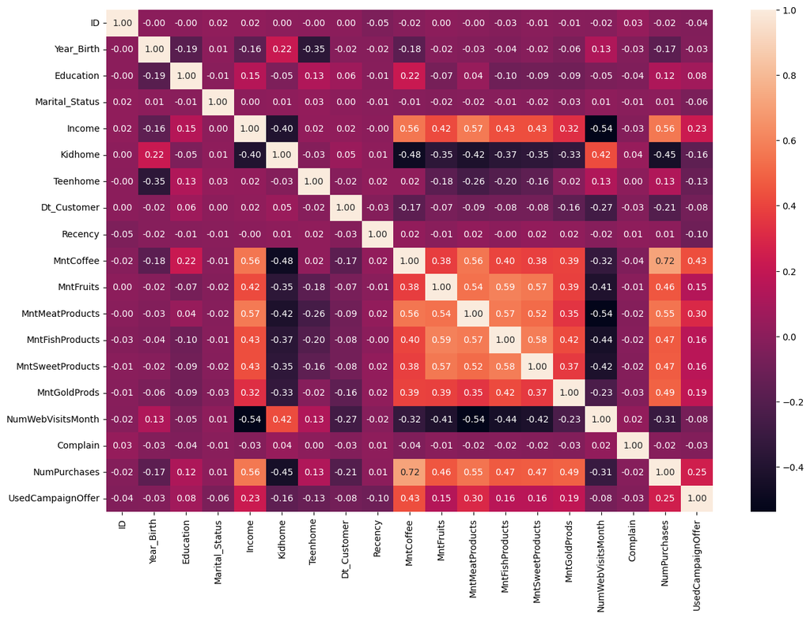

```python
plt.figure(figsize=(15,10))
sns.heatmap(corrData,annot=True,fmt='.2f',annot_kws={"size" : 10})
```

```python
firstDataFrame = dataFrame
```

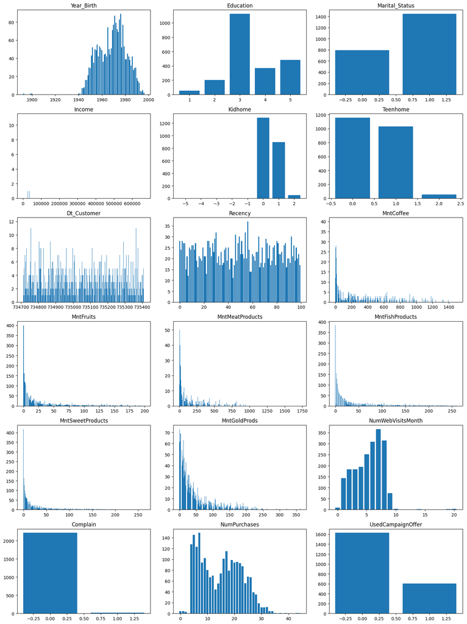

```python
names = firstDataFrame.columns.to_list()[1:]


num_plots = len(names)
rows = num_plots // 3
cols = 3
fig, axs = plt.subplots(nrows=rows, ncols=cols, figsize=(15,20))

for i, feature in enumerate(names):
    row = i // 3
    col = i % 3

    counts = firstDataFrame[feature].value_counts().sort_index()
    axs[row, col].bar(counts.index, counts.values)

    axs[row, col].set_title(feature)

plt.tight_layout()
plt.show()
```

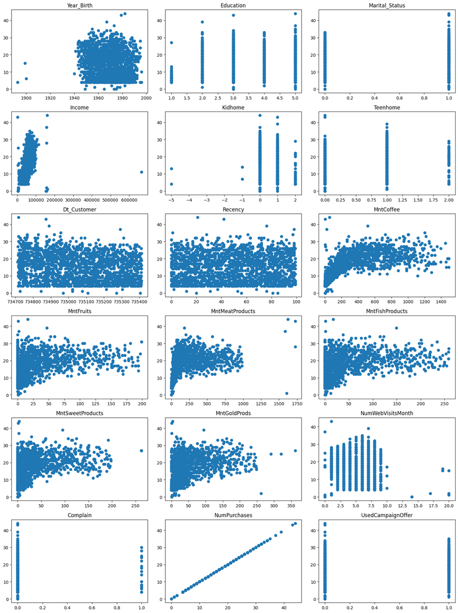

```python
names = firstDataFrame.columns.to_list()[1:]

num_plots = len(names)
rows = num_plots // 3
cols = 3
fig, axs = plt.subplots(nrows=rows, ncols=cols, figsize=(15,20))

for i, feature in enumerate(names):
    row = i // 3
    col = i % 3
    axs[row, col].scatter(dataFrame[feature], dataFrame['NumPurchases'])
    axs[row, col].set_title(feature)

plt.tight_layout()
plt.show()
```

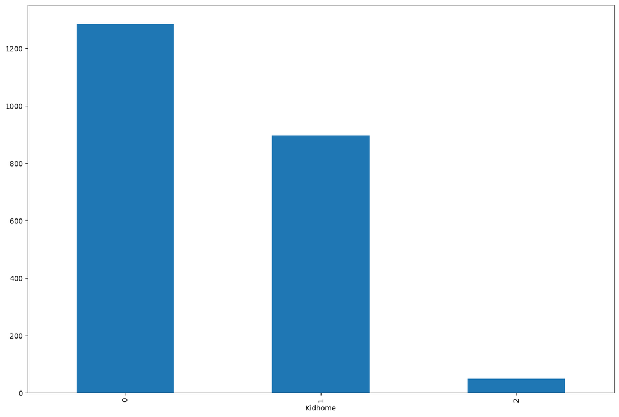

```python
dataFrame = dataFrame[dataFrame['Kidhome'] >= 0]
plt.figure(figsize=(15,10))
dataFrame['Kidhome'].value_counts().sort_index().plot.bar()
plt.show()
```

```python
display(dataFrame)
```

|  | ID | Year_Birth | Education | Marital_Status | Income | Kidhome | Teenhome | Dt_Customer | Recency | MntCoffee | MntFruits | MntMeatProducts | MntFishProducts | MntSweetProducts | MntGoldProds | NumWebVisitsMonth | Complain | NumPurchases | UsedCampaignOffer |
| --- | --- | --- | --- | --- | --- | --- | --- | --- | --- | --- | --- | --- | --- | --- | --- | --- | --- | --- | --- |
| 0 | 5524 | 1957 | 3 | 0 | 58138.0 | 0 | 0 | 734749 | 58 | 635.0 | 88 | 546 | 172 | 88 | 88.0 | NaN | 0 | 25 | 1 |
| 1 | 2174 | 1954 | 3 | 0 | 46344.0 | 1 | 1 | 735299 | 38 | NaN | 1 | 6 | 2 | 1 | 6.0 | 5.0 | 0 | 6 | 0 |
| 2 | 4141 | 1965 | 3 | 1 | 71613.0 | 0 | 0 | 735100 | 26 | NaN | 49 | 127 | 111 | 21 | 42.0 | NaN | 0 | 21 | 0 |
| 3 | 6182 | 1984 | 3 | 1 | 26646.0 | 1 | 0 | 735273 | 26 | 11.0 | 4 | 20 | 10 | 3 | 5.0 | 6.0 | 0 | 8 | 0 |
| 4 | 5324 | 1981 | 5 | 1 | 58293.0 | 1 | 0 | 735251 | 94 | 173.0 | 43 | 118 | 46 | 27 | 15.0 | 5.0 | 0 | 19 | 0 |
| ... | ... | ... | ... | ... | ... | ... | ... | ... | ... | ... | ... | ... | ... | ... | ... | ... | ... | ... | ... |
| 2235 | 10870 | 1967 | 3 | 1 | 61223.0 | 0 | 1 | 735031 | 46 | 709.0 | 43 | 182 | 42 | 118 | 247.0 | 5.0 | 0 | 18 | 0 |
| 2236 | 4001 | 1946 | 5 | 1 | 64014.0 | 2 | 1 | 735393 | 56 | 406.0 | 0 | 30 | 0 | 0 | 8.0 | 7.0 | 0 | 22 | 1 |
| 2237 | 7270 | 1981 | 3 | 0 | 56981.0 | 0 | 0 | 735257 | 91 | 908.0 | 48 | 217 | 32 | 12 | 24.0 | 6.0 | 0 | 19 | 1 |
| 2238 | 8235 | 1956 | 4 | 1 | 69245.0 | 0 | 1 | 735256 | 8 | 428.0 | 30 | 214 | 80 | 30 | 61.0 | NaN | 0 | 23 | 0 |
| 2239 | 9405 | 1954 | 5 | 1 | 52869.0 | 1 | 1 | 734790 | 40 | 84.0 | 3 | 61 | 2 | 1 | 21.0 | 7.0 | 0 | 11 | 1 |

2232 rows × 19 columns

```python
names = list(set(firstDataFrame.columns.to_list()[1:]) - set(['Complain','UsedCampaignOffer','Marital_Status','Education','Kidhome','Teenhome']))
for feature in names:
    dataFrame = dataFrame[(dataFrame[feature].isnull()) | (np.abs(dataFrame[feature] - dataFrame[feature].mean()) <= (3*dataFrame[feature].std()))]
```

```python
missList = ["Income","MntCoffee","MntGoldProds","NumWebVisitsMonth"]
for feature in missList:
    dataFrame[feature] = dataFrame[feature].fillna(round(dataFrame[feature].mean()))
```

```python
display(dataFrame)
```

|  | ID | Year_Birth | Education | Marital_Status | Income | Kidhome | Teenhome | Dt_Customer | Recency | MntCoffee | MntFruits | MntMeatProducts | MntFishProducts | MntSweetProducts | MntGoldProds | NumWebVisitsMonth | Complain | NumPurchases | UsedCampaignOffer |
| --- | --- | --- | --- | --- | --- | --- | --- | --- | --- | --- | --- | --- | --- | --- | --- | --- | --- | --- | --- |
| 0 | 5524 | 1957 | 3 | 0 | 58138.0 | 0 | 0 | 734749 | 58 | 635.0 | 88 | 546 | 172 | 88 | 88.0 | 6.0 | 0 | 25 | 1 |
| 1 | 2174 | 1954 | 3 | 0 | 46344.0 | 1 | 1 | 735299 | 38 | 260.0 | 1 | 6 | 2 | 1 | 6.0 | 5.0 | 0 | 6 | 0 |
| 2 | 4141 | 1965 | 3 | 1 | 71613.0 | 0 | 0 | 735100 | 26 | 260.0 | 49 | 127 | 111 | 21 | 42.0 | 6.0 | 0 | 21 | 0 |
| 3 | 6182 | 1984 | 3 | 1 | 26646.0 | 1 | 0 | 735273 | 26 | 11.0 | 4 | 20 | 10 | 3 | 5.0 | 6.0 | 0 | 8 | 0 |
| 4 | 5324 | 1981 | 5 | 1 | 58293.0 | 1 | 0 | 735251 | 94 | 173.0 | 43 | 118 | 46 | 27 | 15.0 | 5.0 | 0 | 19 | 0 |
| ... | ... | ... | ... | ... | ... | ... | ... | ... | ... | ... | ... | ... | ... | ... | ... | ... | ... | ... | ... |
| 2234 | 8372 | 1974 | 3 | 1 | 48388.0 | 1 | 0 | 735049 | 81 | 3.0 | 3 | 7 | 6 | 2 | 9.0 | 7.0 | 0 | 4 | 0 |
| 2236 | 4001 | 1946 | 5 | 1 | 64014.0 | 2 | 1 | 735393 | 56 | 406.0 | 0 | 30 | 0 | 0 | 8.0 | 7.0 | 0 | 22 | 1 |
| 2237 | 7270 | 1981 | 3 | 0 | 56981.0 | 0 | 0 | 735257 | 91 | 908.0 | 48 | 217 | 32 | 12 | 24.0 | 6.0 | 0 | 19 | 1 |
| 2238 | 8235 | 1956 | 4 | 1 | 69245.0 | 0 | 1 | 735256 | 8 | 428.0 | 30 | 214 | 80 | 30 | 61.0 | 6.0 | 0 | 23 | 0 |
| 2239 | 9405 | 1954 | 5 | 1 | 52869.0 | 1 | 1 | 734790 | 40 | 84.0 | 3 | 61 | 2 | 1 | 21.0 | 7.0 | 0 | 11 | 1 |

1919 rows × 19 columns

```python
normalDF = copy.deepcopy(dataFrame)
idColumn = dataFrame.iloc[:,0]
normalizedDataFrame = dataFrame.iloc[:,1:].apply(lambda x: (x - np.min(x)) / (np.max(x) - np.min(x)))
dfNormalized = pd.concat([idColumn,normalizedDataFrame],axis=1)
display(dfNormalized)
```

|  | ID | Year_Birth | Education | Marital_Status | Income | Kidhome | Teenhome | Dt_Customer | Recency | MntCoffee | MntFruits | MntMeatProducts | MntFishProducts | MntSweetProducts | MntGoldProds | NumWebVisitsMonth | Complain | NumPurchases | UsedCampaignOffer |
| --- | --- | --- | --- | --- | --- | --- | --- | --- | --- | --- | --- | --- | --- | --- | --- | --- | --- | --- | --- |
| 0 | 5524 | 0.303571 | 0.50 | 0.0 | 0.546558 | 0.0 | 0.0 | 0.051502 | 0.585859 | 0.485474 | 0.637681 | 0.754144 | 0.855721 | 0.637681 | 0.497175 | 0.6 | 0.0 | 0.705882 | 1.0 |
| 1 | 2174 | 0.250000 | 0.50 | 0.0 | 0.424549 | 0.5 | 0.5 | 0.838340 | 0.383838 | 0.198777 | 0.007246 | 0.008287 | 0.009950 | 0.007246 | 0.033898 | 0.5 | 0.0 | 0.147059 | 0.0 |
| 2 | 4141 | 0.446429 | 0.50 | 1.0 | 0.685957 | 0.0 | 0.0 | 0.553648 | 0.262626 | 0.198777 | 0.355072 | 0.175414 | 0.552239 | 0.152174 | 0.237288 | 0.6 | 0.0 | 0.588235 | 0.0 |
| 3 | 6182 | 0.785714 | 0.50 | 1.0 | 0.220773 | 0.5 | 0.0 | 0.801144 | 0.262626 | 0.008410 | 0.028986 | 0.027624 | 0.049751 | 0.021739 | 0.028249 | 0.6 | 0.0 | 0.205882 | 0.0 |
| 4 | 5324 | 0.732143 | 1.00 | 1.0 | 0.548161 | 0.5 | 0.0 | 0.769671 | 0.949495 | 0.132263 | 0.311594 | 0.162983 | 0.228856 | 0.195652 | 0.084746 | 0.5 | 0.0 | 0.529412 | 0.0 |
| ... | ... | ... | ... | ... | ... | ... | ... | ... | ... | ... | ... | ... | ... | ... | ... | ... | ... | ... | ... |
| 2234 | 8372 | 0.607143 | 0.50 | 1.0 | 0.445694 | 0.5 | 0.0 | 0.480687 | 0.818182 | 0.002294 | 0.021739 | 0.009669 | 0.029851 | 0.014493 | 0.050847 | 0.7 | 0.0 | 0.088235 | 0.0 |
| 2236 | 4001 | 0.107143 | 1.00 | 1.0 | 0.607345 | 1.0 | 0.5 | 0.972818 | 0.565657 | 0.310398 | 0.000000 | 0.041436 | 0.000000 | 0.000000 | 0.045198 | 0.7 | 0.0 | 0.617647 | 1.0 |
| 2237 | 7270 | 0.732143 | 0.50 | 0.0 | 0.534589 | 0.0 | 0.0 | 0.778255 | 0.919192 | 0.694190 | 0.347826 | 0.299724 | 0.159204 | 0.086957 | 0.135593 | 0.6 | 0.0 | 0.529412 | 1.0 |
| 2238 | 8235 | 0.285714 | 0.75 | 1.0 | 0.661460 | 0.0 | 0.5 | 0.776824 | 0.080808 | 0.327217 | 0.217391 | 0.295580 | 0.398010 | 0.217391 | 0.344633 | 0.6 | 0.0 | 0.647059 | 0.0 |
| 2239 | 9405 | 0.250000 | 1.00 | 1.0 | 0.492050 | 0.5 | 0.5 | 0.110157 | 0.404040 | 0.064220 | 0.021739 | 0.084254 | 0.009950 | 0.007246 | 0.118644 | 0.7 | 0.0 | 0.294118 | 1.0 |

1919 rows × 19 columns

```python
numOfTrain = int(dfNormalized.shape[0] * (8/10))
dfNormalized = dfNormalized.sample(frac=1)
trainData = copy.deepcopy(dfNormalized[:numOfTrain])
testData = copy.deepcopy(dfNormalized[numOfTrain:])
display(trainData)
display(testData)
```

|  | ID | Year_Birth | Education | Marital_Status | Income | Kidhome | Teenhome | Dt_Customer | Recency | MntCoffee | MntFruits | MntMeatProducts | MntFishProducts | MntSweetProducts | MntGoldProds | NumWebVisitsMonth | Complain | NumPurchases | UsedCampaignOffer |
| --- | --- | --- | --- | --- | --- | --- | --- | --- | --- | --- | --- | --- | --- | --- | --- | --- | --- | --- | --- |
| 737 | 6255 | 0.214286 | 0.75 | 1.0 | 0.674908 | 0.0 | 0.5 | 0.962804 | 0.292929 | 0.105505 | 0.282609 | 0.087017 | 0.273632 | 0.130435 | 0.118644 | 0.2 | 0.0 | 0.352941 | 0.0 |
| 891 | 7108 | 0.446429 | 0.75 | 0.0 | 0.476750 | 0.5 | 0.5 | 0.057225 | 0.545455 | 0.156728 | 0.144928 | 0.064917 | 0.114428 | 0.014493 | 0.316384 | 0.5 | 0.0 | 0.500000 | 0.0 |
| 1260 | 5107 | 0.589286 | 1.00 | 0.0 | 0.316092 | 0.5 | 0.5 | 0.941345 | 0.373737 | 0.198777 | 0.000000 | 0.011050 | 0.019900 | 0.014493 | 0.112994 | 0.5 | 0.0 | 0.147059 | 1.0 |
| 277 | 7828 | 0.732143 | 0.75 | 1.0 | 0.750809 | 0.0 | 0.0 | 0.914163 | 0.292929 | 0.051988 | 0.934783 | 0.546961 | 0.935323 | 0.159420 | 0.084746 | 0.1 | 0.0 | 0.323529 | 0.0 |
| 263 | 9396 | 0.678571 | 1.00 | 1.0 | 0.445694 | 0.5 | 0.0 | 0.165951 | 0.313131 | 0.006881 | 0.000000 | 0.008287 | 0.019900 | 0.007246 | 0.028249 | 0.9 | 0.0 | 0.088235 | 0.0 |
| ... | ... | ... | ... | ... | ... | ... | ... | ... | ... | ... | ... | ... | ... | ... | ... | ... | ... | ... | ... |
| 710 | 1940 | 0.821429 | 0.50 | 1.0 | 0.206352 | 0.5 | 0.0 | 0.496423 | 0.262626 | 0.000765 | 0.021739 | 0.005525 | 0.009950 | 0.014493 | 0.033898 | 0.8 | 0.0 | 0.088235 | 0.0 |
| 1711 | 7832 | 0.339286 | 0.75 | 1.0 | 0.747065 | 0.0 | 0.5 | 0.563662 | 0.303030 | 0.198777 | 0.318841 | 0.546961 | 0.000000 | 0.637681 | 0.327684 | 0.4 | 0.0 | 0.647059 | 1.0 |
| 1194 | 2245 | 0.517857 | 0.75 | 1.0 | 0.396586 | 0.5 | 0.5 | 0.380544 | 0.505051 | 0.043578 | 0.014493 | 0.070442 | 0.019900 | 0.014493 | 0.129944 | 0.6 | 0.0 | 0.264706 | 0.0 |
| 125 | 1491 | 0.446429 | 0.25 | 1.0 | 0.684664 | 0.0 | 0.0 | 0.290415 | 0.878788 | 0.123853 | 0.239130 | 0.171271 | 0.199005 | 0.202899 | 0.971751 | 0.1 | 0.0 | 0.441176 | 0.0 |
| 1254 | 5011 | 0.410714 | 0.50 | 0.0 | 0.649801 | 0.0 | 0.5 | 0.636624 | 0.515152 | 0.454893 | 0.166667 | 0.169890 | 0.049751 | 0.166667 | 0.870056 | 0.6 | 0.0 | 0.647059 | 0.0 |

1535 rows × 19 columns

|  | ID | Year_Birth | Education | Marital_Status | Income | Kidhome | Teenhome | Dt_Customer | Recency | MntCoffee | MntFruits | MntMeatProducts | MntFishProducts | MntSweetProducts | MntGoldProds | NumWebVisitsMonth | Complain | NumPurchases | UsedCampaignOffer |
| --- | --- | --- | --- | --- | --- | --- | --- | --- | --- | --- | --- | --- | --- | --- | --- | --- | --- | --- | --- |
| 1611 | 1773 | 0.678571 | 0.25 | 1.0 | 0.073325 | 0.0 | 0.0 | 0.181688 | 0.383838 | 0.003823 | 0.043478 | 0.020718 | 0.054726 | 0.050725 | 0.073446 | 0.9 | 0.0 | 0.147059 | 0.0 |
| 726 | 6086 | 0.267857 | 0.50 | 1.0 | 0.776806 | 0.0 | 0.0 | 0.688126 | 0.626263 | 0.340214 | 0.181159 | 0.975138 | 0.398010 | 0.550725 | 0.271186 | 0.2 | 0.0 | 0.676471 | 1.0 |
| 2003 | 6679 | 0.464286 | 0.50 | 0.0 | 0.445694 | 0.0 | 0.0 | 0.975680 | 0.292929 | 0.007645 | 0.021739 | 0.004144 | 0.000000 | 0.000000 | 0.000000 | 0.3 | 0.0 | 0.088235 | 0.0 |
| 823 | 3855 | 0.410714 | 0.50 | 1.0 | 0.445694 | 0.0 | 0.0 | 0.374821 | 0.747475 | 0.022936 | 0.021739 | 0.064917 | 0.094527 | 0.152174 | 0.237288 | 0.8 | 0.0 | 0.205882 | 0.0 |
| 553 | 9460 | 0.410714 | 0.50 | 1.0 | 0.177044 | 0.0 | 0.0 | 0.374821 | 0.747475 | 0.022936 | 0.021739 | 0.064917 | 0.094527 | 0.152174 | 0.237288 | 0.8 | 0.0 | 0.205882 | 0.0 |
| ... | ... | ... | ... | ... | ... | ... | ... | ... | ... | ... | ... | ... | ... | ... | ... | ... | ... | ... | ... |
| 965 | 7801 | 0.339286 | 0.50 | 1.0 | 0.511540 | 0.0 | 0.5 | 0.585122 | 0.878788 | 0.150612 | 0.775362 | 0.313536 | 0.034826 | 0.427536 | 0.740113 | 0.6 | 0.0 | 0.588235 | 0.0 |
| 777 | 4964 | 0.321429 | 1.00 | 1.0 | 0.713236 | 0.0 | 0.0 | 0.779685 | 0.909091 | 0.519878 | 0.079710 | 0.541436 | 0.373134 | 0.000000 | 0.000000 | 0.1 | 0.0 | 0.500000 | 0.0 |
| 1820 | 2415 | 0.392857 | 0.50 | 1.0 | 0.445694 | 0.0 | 0.5 | 0.881259 | 1.000000 | 0.276758 | 0.123188 | 0.549724 | 0.398010 | 0.253623 | 0.344633 | 0.4 | 0.0 | 0.441176 | 1.0 |
| 604 | 1177 | 0.464286 | 0.75 | 1.0 | 0.445694 | 0.5 | 0.5 | 0.257511 | 0.777778 | 0.061162 | 0.021739 | 0.035912 | 0.019900 | 0.014493 | 0.079096 | 0.7 | 0.0 | 0.294118 | 0.0 |
| 1357 | 7712 | 0.107143 | 1.00 | 0.0 | 0.588155 | 0.0 | 0.0 | 0.911302 | 0.686869 | 0.139144 | 0.123188 | 0.357735 | 0.383085 | 0.507246 | 0.163842 | 0.4 | 0.0 | 0.529412 | 0.0 |

384 rows × 19 columns

# Linear Regression

Main form of simple linear regression function: $$f(x) = \alpha x + \beta$$

- step 1: Compute RSS of the training data

$$ RSS = \Sigma (y_i - (\hat{\beta} + \hat{\alpha} * x_i) )^2 $$

- step 2: Compute the derivatives of the RSS function in terms of $\alpha$ and $\beta$, and set them equal to 0 to find the desired parameters

$$ \frac{\partial RSS}{\partial \beta} = \Sigma (-f(x_i) + \hat{\beta} + \hat{\alpha} * x_i) = 0$$$$ \to \beta = \hat{y} - \hat{\alpha} \hat{x} \to (1)$$$$ \frac{\partial RSS}{\partial \alpha} = \Sigma (-2 x_i y_i + 2 \hat{\beta} x_i + 2\hat{\alpha} x_i ^ 2) = 0 \to (2)$$$$ (1) , (2) \to \hat{\alpha} = \frac{\Sigma{(x_i - \hat{x})(y_i - \hat{y})}}{\Sigma{(x_i - \hat{x})^2}} $$$$ \hat{\beta} = y - \hat{a} x$$

Based on the above formula, implement the function below to compute the parameters of a simple linear regression

```python
def simple_linear_regression(input_feature, output):
    xBar = np.mean(input_feature)
    yBar = np.mean(output)
    sig = 0
    dis = 0
    for i in range(len(input_feature)):
        sig += (input_feature[i] - xBar) * (output[i] - yBar)
        dis += (input_feature[i] - xBar)**2
    a = sig / dis
    b = yBar - a*xBar

    return a, b
```

Now complete this `get_regression_predictions(...)` function to predict the value of given data based on the calculated intercept and slope

```python
def get_regression_predictions(input_feature, bias, slope):
    output = input_feature * slope + bias
    return output
```

Now that we have a model and can make predictions, let's evaluate our model using Root Mean Square Error (RMSE). RMSE is the square root of the mean of the squared differences between the residuals, and the residuals is just a fancy word for the difference between the predicted output and the true output.

Complete the following function to compute the RSME of a simple linear regression model given the input_feature, output, intercept and slope:

```python
def get_root_mean_square_error(predicted_values, outputs):
    Mse = 0
    for predict, actual in zip(predicted_values, outputs):
        error = actual - predict
        Mse += error**2
    Mse = Mse/len(predicted_values)
    Rmse = np.sqrt(Mse)
    return Rmse
```

The RMSE has no bound, thus it becomes challenging to determine whether a particular RMSE value is considered good or bad without any reference point. Instead, we use R2 score. The R2 score is calculated by comparing the sum of the squared differences between the actual and predicted values of the dependent variable to the total sum of squared differences between the actual and mean values of the dependent variable. The R2 score is formulated as below:

$$R^2 = 1 - \frac{SSres}{SStot} = 1 - \frac{\sum_{i=1}^{n} (y_{i,true} - y_{i,pred})^2}{\sum_{i=1}^{n} (y_{i,true} - \bar{y}_{true})^2} $$

Complete the following function to calculate the R2 score of a given input_feature, output, bias, and slope:

```python
def get_r2_score(predicted_values, outputs):
    SSres = 0
    SStot = 0
    for i in range(len(outputs)):
        SSres += (outputs[i] - predicted_values[i])**2
    for i in range(len(outputs)):
        SStot += (outputs[i] - np.mean(outputs))**2
    return 1 - (SSres /SStot)
```

Now calculate the fitness of the model. Remember to provide explanation for the outputs in your code!

```python
featureNames = ['MntCoffee','Income','MntGoldProds','MntMeatProducts']
designated_feature_list = []

for feature in featureNames:
    designated_feature_list.append(trainData[feature].to_list())

outputList = trainData['NumPurchases'].to_list()
alphaBetaList = []
for i in range(4):
    alpha,beta = simple_linear_regression(designated_feature_list[i],outputList)
    alphaBetaList.append((alpha,beta))

test_feature_list = []

for feature in featureNames:
    test_feature_list.append(testData[feature].to_list())

predictOutList = []

for i in range(4):
    out = []
    for j in range(len(test_feature_list[i])):
        output = get_regression_predictions(test_feature_list[i][j],alphaBetaList[i][1],alphaBetaList[i][0])
        out.append(output)
    predictOutList.append(out)



ScoreDict = {}

for i in range(len(predictOutList)):
    rmse = get_root_mean_square_error(predictOutList[i],testData['NumPurchases'].to_list())
    r2 = get_r2_score(predictOutList[i],testData['NumPurchases'].to_list())
    ScoreDict[featureNames[i]] = {'R2' : r2 , 'RMSE' : rmse}

scoreDataFrame = pd.DataFrame(ScoreDict).T
display(scoreDataFrame)
# ToDo
#  measure the performance of the simple linear regression model
```

|  | R2 | RMSE |
| --- | --- | --- |
| MntCoffee | 0.518792 | 0.153289 |
| Income | 0.492151 | 0.157475 |
| MntGoldProds | 0.307608 | 0.183874 |
| MntMeatProducts | 0.384106 | 0.173419 |

# Multiple Regression

Multiple regression is a statistical technique that aims to model the relationship between a dependent variable and two or more independent variables.

Multiple regression with n independent variables is expressed as follows:

$$f(x) = \beta _{0} + \beta_{1} x_{1} + \beta_{2} x_{2} + \beta_{3} x_{3} + \beta_{4} x_{4} + ... + \beta_{n} x_{n} + c $$

To optimize the model for accurate predictions, multiple regression commonly employs iterative algorithms such as gradient descent.

The main goal of the optimization process is to make our predictions as close as possible to the actual values. We measure the prediction error using a cost function, usually denoted as $J(\beta)$.

$$ J(\beta)= \frac {1}{2m} Σ_{i=0}^{m-1}(y_i - (\hat \beta _{0} + \hat \beta_{1} x_{1} + \hat \beta_{2} x_{2} + \hat \beta_{3} x_{3} + \hat \beta_{4} x_{4} + ... + \hat \beta_{n} x_{n}) )^2 $$

Gradient descent iteratively adjusts the coefficients $(\beta_i)$ to minimize the cost function. The update rule for each coefficient is:

$$\beta_{i} = \beta _ {i} - \alpha \frac {∂J(\beta)}{∂\beta_{i}}$$$$ \frac {∂J(\beta)}{∂\beta_{i}} = \frac {1}{m}Σ_{j=0}^{m-1}(y_j - (\hat \beta _{0} + \hat \beta_{1} x_{j1} + \hat \beta_{2} x_{j2} + \hat \beta_{3} x_{j3} + \hat \beta_{4} x_{j4} + ... + \hat \beta_{n} x_{jn})) x_{ji} $$

## Predicting output given regression weights

Based on the formula above and [np.dot()](https://numpy.org/doc/stable/reference/generated/numpy.dot.html) method, complete this function to compute the predictions for an entire matrix of features given the matrix, bias, and the weights. Provide an explanation of np.dot method and the reasoning behind using this method in your code:

```python
def predict_output(feature_matrix, weights, bias):
    return np.dot(feature_matrix, weights) + bias
```

## Computing the Derivative

As we saw, the cost function is the sum over the data points of the squared difference between an observed output and a predicted output.

Since the derivative of a sum is the sum of the derivatives, we can compute the derivative for a single data point and then sum over data points. We can write the squared difference between the observed output and predicted output for a single point as follows:

$$ (output - (const* w _{0} + [feature_1] * w_{1} + ...+ [feature_n] * w_{n} ))^2 $$

With n feautures and a const , So the derivative will be :

$$ 2 * (output - (const* w _{0} + [feature_1] * w_{1} + ...+ [feature_n] * w_{n} )) $$

The term inside the paranethesis is just the error (difference between prediction and output). So we can re-write this as:

$$2 * error*[feature_i] $$

That is, the derivative for the weight for feature i is the sum (over data points) of 2 times the product of the error and the feature itself. In the case of the constant then this is just twice the sum of the errors!

Recall that twice the sum of the product of two vectors is just twice the dot product of the two vectors. Therefore the derivative for the weight for feature_i is just two times the dot product between the values of feature_i and the current errors.

With this in mind, complete the following derivative function which computes the derivative of the weight given the value of the feature (over all data points) and the errors (over all data points).

```python
def feature_derivative(errors, feature):
    return 2 * np.dot(errors, feature)
```

## Gradient Descent

Now we will write a function that performs a gradient descent. The basic premise is simple. Given a starting point we update the current weights by moving in the negative gradient direction. Recall that the gradient is the direction of increase and therefore the negative gradient is the direction of decrease and we're trying to minimize a cost function.

The amount by which we move in the negative gradient direction is called the 'step size'. We stop when we are 'sufficiently close' to the optimum. We define this by requiring that the magnitude (length) of the gradient vector to be smaller than a fixed 'tolerance'.

With this in mind, complete the following gradient descent function below using your derivative function above. For each step in the gradient descent we update the weight for each feature befofe computing our stopping criteria.

```python
def regression_gradient_descent(feature_matrix, outputs, initial_weights, bias, step_size, tolerance):

    converged = False
    weights = np.array(initial_weights)
    newBias = bias

    while not converged:

        predictions = predict_output(feature_matrix, weights, newBias)
        errors = predictions - outputs


        newBias -= step_size * 2 * np.sum(errors)

        for i in range(len(weights)):
            derivative = feature_derivative(errors, feature_matrix[:,i])
            weights[i] -= step_size * derivative

        gradientMagnitude = np.linalg.norm(feature_derivative(errors, feature_matrix))
        biasGradient = np.linalg.norm(2 * np.sum(errors))

        if gradientMagnitude < tolerance and biasGradient < tolerance:
            converged = True


    return weights, newBias
```

```python
# Utility functions for multiple regression

def normalize_features(chosen_features, data_frame):
    for feature in chosen_features:
        data_frame[feature] = (data_frame[feature] - data_frame[feature].mean()) / data_frame[feature].std()
    return data_frame


def n_feature_regression(chosen_feature_matrix, target_matrix, keywords):
    initial_weights = keywords['initial_weights']
    step_size = keywords['step_size']
    tolerance = keywords['tolerance']
    bias = keywords['bias']

    weights, bias = regression_gradient_descent(chosen_feature_matrix, target_matrix, initial_weights, bias, step_size,
                                                tolerance)

    return weights, bias

def get_weights_and_bias(chosen_features):
    """
    Computes the weights and bias for a general n feature model.
    :param chosen_features:  list of features to perform multiple regression on
    :return: chosen_feature_matrix, computed weights and bias via regression
    """

    # ToDo
    #  Would selecting different initial weights make any difference?
    #  Explain your answer.
    keywords = {
        'initial_weights': np.array([.5]*len(chosen_features)),
        'step_size': 1.e-4,
        'tolerance': 1.e-10,
        'bias': 0
    }


    chosen_feature_dataframe = copy.deepcopy(trainData[chosen_features])
    # ToDo
    #  Why are the features normalized?
    chosen_feature_dataframe = normalize_features(chosen_features,chosen_feature_dataframe)
    chosen_feature_matrix = chosen_feature_dataframe.to_numpy()

    target_column = copy.deepcopy(trainData['NumPurchases'])
    target_matrix = target_column.to_numpy()

    train_weights, bias = n_feature_regression(chosen_feature_matrix, target_matrix, keywords)

    return chosen_feature_matrix, train_weights, bias
```

Because it is possible to converge to a local optimum, changing the initial weights may improve or worsen the result compared to the past.

Normalizing causes the model to converge faster and achieve better results.

## Two Feature Regression

In this part, you should choose 2 features and implement multiple regression on them :

```python
chosen_features = ['Income', 'MntCoffee']
featureMatrix,weights,bias = get_weights_and_bias(chosen_features)
 # ToDo
# ToDo
# compute the chosen_feature_matrix, train_weights, and bias
```

```python
#ToDo
# compute the predictions
testFeatures = copy.deepcopy(testData[chosen_features])
testFeaturesn = normalize_features(chosen_features,testFeatures).to_numpy()
testOut = copy.deepcopy(testData['NumPurchases']).to_numpy()
predict = predict_output(testFeaturesn,weights,bias)
#print(predict)
#print(testOut)
```

```python
#ToDo
# Calculate the R2 score and mean square error
# Explain the results
print("R2 score : ",get_r2_score(predict,testOut))
print("RMSE : ",get_root_mean_square_error(predict,testOut))
```

```
R2 score :  0.6157011480953203
RMSE :  0.13698694109810616
```

The R2 value has improved compared to single variable regression, and the rmse value has also decreased.

## Three Feature Regression

Now repeat the steps for 3 features

```python
# ToDo
chosen_features = ['Income', 'MntCoffee', 'MntGoldProds']
featureMatrix,weights,bias = get_weights_and_bias(chosen_features)
testFeatures = copy.deepcopy(testData[chosen_features])
testFeaturesn = normalize_features(chosen_features,testFeatures).to_numpy()
testOut = copy.deepcopy(testData['NumPurchases']).to_numpy()
predict = predict_output(testFeaturesn,weights,bias)
print("R2 score : ",get_r2_score(predict,testOut))
print("RMSE : ",get_root_mean_square_error(predict,testOut))
```

```
R2 score :  0.6667961890680172
RMSE :  0.12755562189141112
```

## Five Feature Regression

Finally, repeat the steps for 5 features

Explain the differences in the results and the reasoning behind these variations.

```python
# ToDo
chosen_features = ['Income', 'MntCoffee', 'MntFruits', 'MntGoldProds', 'NumWebVisitsMonth']
featureMatrix,weights,bias = get_weights_and_bias(chosen_features)
testFeatures = copy.deepcopy(testData[chosen_features])
testFeaturesn = normalize_features(chosen_features,testFeatures).to_numpy()
testOut = copy.deepcopy(testData['NumPurchases']).to_numpy()
predict = predict_output(testFeaturesn,weights,bias)
print("R2 score : ",get_r2_score(predict,testOut))
print("RMSE : ",get_root_mean_square_error(predict,testOut))
```

```
R2 score :  0.6834770221405502
RMSE :  0.12432178755913284
```

## PART 3

```python
newDataFrame = copy.deepcopy(dfNormalized)
median = newDataFrame['NumPurchases'].median()
newDataFrame['PurchaseRate'] = ['HIGH' if x > median else 'LOW' for x in newDataFrame['NumPurchases']]
```

```python
display(newDataFrame)
```

|  | ID | Year_Birth | Education | Marital_Status | Income | Kidhome | Teenhome | Dt_Customer | Recency | MntCoffee | MntFruits | MntMeatProducts | MntFishProducts | MntSweetProducts | MntGoldProds | NumWebVisitsMonth | Complain | NumPurchases | UsedCampaignOffer | PurchaseRate |
| --- | --- | --- | --- | --- | --- | --- | --- | --- | --- | --- | --- | --- | --- | --- | --- | --- | --- | --- | --- | --- |
| 737 | 6255 | 0.214286 | 0.75 | 1.0 | 0.674908 | 0.0 | 0.5 | 0.962804 | 0.292929 | 0.105505 | 0.282609 | 0.087017 | 0.273632 | 0.130435 | 0.118644 | 0.2 | 0.0 | 0.352941 | 0.0 | LOW |
| 891 | 7108 | 0.446429 | 0.75 | 0.0 | 0.476750 | 0.5 | 0.5 | 0.057225 | 0.545455 | 0.156728 | 0.144928 | 0.064917 | 0.114428 | 0.014493 | 0.316384 | 0.5 | 0.0 | 0.500000 | 0.0 | HIGH |
| 1260 | 5107 | 0.589286 | 1.00 | 0.0 | 0.316092 | 0.5 | 0.5 | 0.941345 | 0.373737 | 0.198777 | 0.000000 | 0.011050 | 0.019900 | 0.014493 | 0.112994 | 0.5 | 0.0 | 0.147059 | 1.0 | LOW |
| 277 | 7828 | 0.732143 | 0.75 | 1.0 | 0.750809 | 0.0 | 0.0 | 0.914163 | 0.292929 | 0.051988 | 0.934783 | 0.546961 | 0.935323 | 0.159420 | 0.084746 | 0.1 | 0.0 | 0.323529 | 0.0 | LOW |
| 263 | 9396 | 0.678571 | 1.00 | 1.0 | 0.445694 | 0.5 | 0.0 | 0.165951 | 0.313131 | 0.006881 | 0.000000 | 0.008287 | 0.019900 | 0.007246 | 0.028249 | 0.9 | 0.0 | 0.088235 | 0.0 | LOW |
| ... | ... | ... | ... | ... | ... | ... | ... | ... | ... | ... | ... | ... | ... | ... | ... | ... | ... | ... | ... | ... |
| 965 | 7801 | 0.339286 | 0.50 | 1.0 | 0.511540 | 0.0 | 0.5 | 0.585122 | 0.878788 | 0.150612 | 0.775362 | 0.313536 | 0.034826 | 0.427536 | 0.740113 | 0.6 | 0.0 | 0.588235 | 0.0 | HIGH |
| 777 | 4964 | 0.321429 | 1.00 | 1.0 | 0.713236 | 0.0 | 0.0 | 0.779685 | 0.909091 | 0.519878 | 0.079710 | 0.541436 | 0.373134 | 0.000000 | 0.000000 | 0.1 | 0.0 | 0.500000 | 0.0 | HIGH |
| 1820 | 2415 | 0.392857 | 0.50 | 1.0 | 0.445694 | 0.0 | 0.5 | 0.881259 | 1.000000 | 0.276758 | 0.123188 | 0.549724 | 0.398010 | 0.253623 | 0.344633 | 0.4 | 0.0 | 0.441176 | 1.0 | HIGH |
| 604 | 1177 | 0.464286 | 0.75 | 1.0 | 0.445694 | 0.5 | 0.5 | 0.257511 | 0.777778 | 0.061162 | 0.021739 | 0.035912 | 0.019900 | 0.014493 | 0.079096 | 0.7 | 0.0 | 0.294118 | 0.0 | LOW |
| 1357 | 7712 | 0.107143 | 1.00 | 0.0 | 0.588155 | 0.0 | 0.0 | 0.911302 | 0.686869 | 0.139144 | 0.123188 | 0.357735 | 0.383085 | 0.507246 | 0.163842 | 0.4 | 0.0 | 0.529412 | 0.0 | HIGH |

1919 rows × 20 columns

```python
from sklearn.model_selection import GridSearchCV

def GridSearchBestModel(model, param_grid, X, Y):
  grid = GridSearchCV(model, param_grid, cv=5)
  grid.fit(X, Y)
  bestModel = grid.best_estimator_
  bestParams = grid.best_params_
  return bestModel, bestParams
```

```python
from sklearn.metrics import confusion_matrix

def ConfusionMatrix(y_out,y_pred):
    cm = confusion_matrix(y_out, y_pred)
    tp = cm[0][0]
    fn = cm[1][0]
    fp = cm[0][1]
    tn = cm[1][1]
    accuracy = (tp + tn) / (tp + fp + fn + tn)
    return accuracy
```

```python
numOfTrain = int(dfNormalized.shape[0] * (8/10))
newTrainData = copy.deepcopy(newDataFrame[:numOfTrain])
newTestData = copy.deepcopy(newDataFrame[numOfTrain:])
X = newTrainData.drop(['PurchaseRate','NumPurchases'], axis=1)
Y = newTrainData['PurchaseRate']
X_new = newTestData.drop(['PurchaseRate','NumPurchases'], axis=1)
y_out = newTestData['PurchaseRate']
results = {}
```

```python
from sklearn.tree import DecisionTreeClassifier
model = DecisionTreeClassifier()
paramGridDecision = {
    'max_depth': [3, 5, 7, 9],
    'min_samples_split': [2, 5, 7, 10],
    'min_samples_leaf': [1, 5, 8, 10],
}
bestModel,bestParams = GridSearchBestModel(model,paramGridDecision,X,Y)
results['DecisionTree'] = ConfusionMatrix(y_out,bestModel.predict(X_new))
```

```
[Text(0.375, 0.9375, 'x[9] <= 0.091\ngini = 0.5\nsamples = 1535\nvalue = [752, 783]'),
```

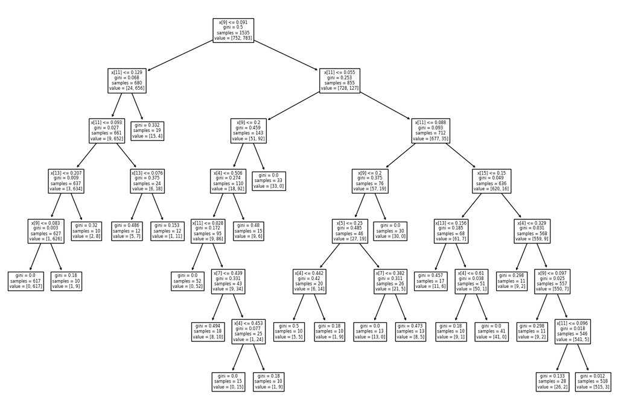

```python
from sklearn.tree import plot_tree
plt.figure(figsize=(15,10))

plot_tree(bestModel)
```

```python
from sklearn.neighbors import KNeighborsClassifier
model = KNeighborsClassifier()
paramGridNeigbors = {
    'n_neighbors': [1,2,3,4,5,6,7,8,9,10,20,30]
}
bestModel,bestParams = GridSearchBestModel(model,paramGridNeigbors,X,Y)
results['KNeighbors'] = ConfusionMatrix(y_out,bestModel.predict(X_new))
```

```python
from sklearn.linear_model import LogisticRegression
model = LogisticRegression()
paramGridLogistic = {
    'C': [1,10, 100],
    'solver': ['newton-cg', 'lbfgs', 'liblinear', 'sag', 'saga'],
    'penalty': ['l1', 'l2'],
    'max_iter': [500,1000,2000,2500]
}
bestModel,bestParams = GridSearchBestModel(model,paramGridLogistic,X,Y)
results['LogisticRegression'] = ConfusionMatrix(y_out,bestModel.predict(X_new))
```

[output not shown]

[output cut: 532 more lines]

[output not shown]

```python
def RandomForst(model):
    model.fit(X, Y)
    return ConfusionMatrix(y_out,model.predict(X_new))
```

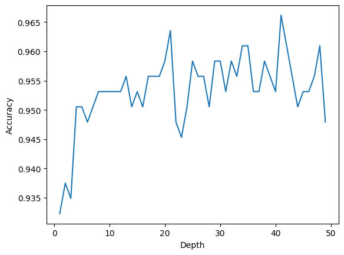

```python
from sklearn.ensemble import RandomForestClassifier

maxDepthChange = []

for maxDepth in range(1,50):
    model = RandomForestClassifier(max_depth=maxDepth)
    maxDepthChange.append((maxDepth,RandomForst(model)))

x = [t[0] for t in maxDepthChange]
y = [t[1] for t in maxDepthChange]

plt.plot(x,y)
plt.xlabel("Depth")
plt.ylabel("Accuracy")
plt.show()
```

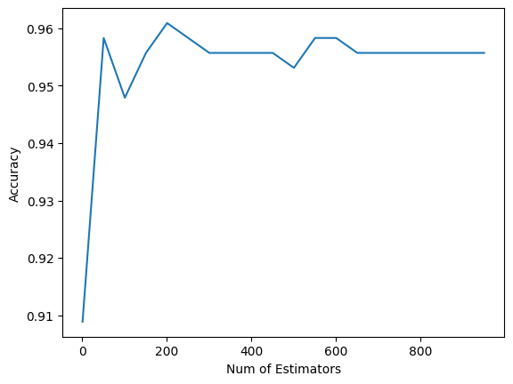

```python
nEstimatorsChange = []

for num in range(1,1000,50):
    model = RandomForestClassifier(n_estimators=num)
    nEstimatorsChange.append((num,RandomForst(model)))

x = [t[0] for t in nEstimatorsChange]
y = [t[1] for t in nEstimatorsChange]

plt.plot(x,y)
plt.xlabel("Num of Estimators")
plt.ylabel("Accuracy")
plt.show()
```

```python
model = RandomForestClassifier()
paramRandomForst = {
    'n_estimators': [50,100,150,200],
    'max_depth': [1,3,5,6,7,10],

}
bestModel,bestParams = GridSearchBestModel(model,paramRandomForst,X,Y)
results['RandomForest'] = ConfusionMatrix(y_out,bestModel.predict(X_new))
```

```python
noiseDataFrame = copy.deepcopy(newDataFrame.drop(['PurchaseRate','ID'],axis=1))
featuresNoise = list(set(newDataFrame.columns.to_list()[1:]) - set(['Complain','UsedCampaignOffer','Marital_Status','Education','Kidhome','Teenhome','PurchaseRate']))
scale = 0.1
noise = np.random.laplace(loc=0, scale=scale, size=noiseDataFrame[featuresNoise].shape)
noiseDataFrame[featuresNoise] += noise
idColumn = newDataFrame.iloc[:,0]
purchaseRateColumn = newDataFrame.iloc[:,-1]
noiseDataFrame = pd.concat([idColumn,noiseDataFrame,purchaseRateColumn],axis=1)

display(noiseDataFrame)
```

|  | ID | Year_Birth | Education | Marital_Status | Income | Kidhome | Teenhome | Dt_Customer | Recency | MntCoffee | MntFruits | MntMeatProducts | MntFishProducts | MntSweetProducts | MntGoldProds | NumWebVisitsMonth | Complain | NumPurchases | UsedCampaignOffer | PurchaseRate |
| --- | --- | --- | --- | --- | --- | --- | --- | --- | --- | --- | --- | --- | --- | --- | --- | --- | --- | --- | --- | --- |
| 737 | 6255 | 0.245134 | 0.75 | 1.0 | 0.700408 | 0.0 | 0.5 | 0.753826 | 0.201367 | -0.003303 | 0.275386 | 0.166833 | 0.434112 | 0.100801 | 0.186222 | 0.007732 | 0.0 | 0.302755 | 0.0 | LOW |
| 891 | 7108 | 0.432106 | 0.75 | 0.0 | 0.531449 | 0.5 | 0.5 | 0.164233 | 0.556802 | -0.128898 | 0.069858 | -0.027857 | 0.068111 | 0.193536 | 0.406036 | 0.444568 | 0.0 | 0.494322 | 0.0 | HIGH |
| 1260 | 5107 | 0.852156 | 1.00 | 0.0 | -0.033355 | 0.5 | 0.5 | 0.903686 | 0.603727 | 0.246302 | 0.025912 | -0.007133 | -0.119193 | 0.053506 | 0.250664 | 0.560831 | 0.0 | 0.056913 | 1.0 | LOW |
| 277 | 7828 | 0.700703 | 0.75 | 1.0 | 0.714265 | 0.0 | 0.0 | 0.807183 | 0.435850 | 0.035517 | 0.944018 | 0.559217 | 0.974008 | 0.134692 | 0.091827 | 0.091503 | 0.0 | 0.183009 | 0.0 | LOW |
| 263 | 9396 | 0.540166 | 1.00 | 1.0 | 0.465677 | 0.5 | 0.0 | 0.280001 | 0.485108 | 0.256035 | 0.128848 | -0.080441 | 0.013864 | 0.052740 | 0.049299 | 0.755302 | 0.0 | 0.031525 | 0.0 | LOW |
| ... | ... | ... | ... | ... | ... | ... | ... | ... | ... | ... | ... | ... | ... | ... | ... | ... | ... | ... | ... | ... |
| 965 | 7801 | 0.273424 | 0.50 | 1.0 | 0.372925 | 0.0 | 0.5 | 0.537929 | 0.921509 | 0.189839 | 0.695877 | 0.317017 | 0.033707 | 0.424411 | 0.451255 | 0.494747 | 0.0 | 0.599802 | 0.0 | HIGH |
| 777 | 4964 | 0.451044 | 1.00 | 1.0 | 0.564694 | 0.0 | 0.0 | 0.770746 | 0.884878 | 0.519746 | 0.172729 | 0.449620 | 0.556778 | -0.023384 | -0.253754 | -0.100423 | 0.0 | 0.337789 | 0.0 | HIGH |
| 1820 | 2415 | 0.393179 | 0.50 | 1.0 | 0.459148 | 0.0 | 0.5 | 0.817478 | 1.214914 | 0.336455 | 0.193737 | 0.551383 | 0.413350 | 0.235842 | 0.594166 | 0.431471 | 0.0 | 0.430483 | 1.0 | HIGH |
| 604 | 1177 | 0.542505 | 0.75 | 1.0 | 0.361274 | 0.5 | 0.5 | 0.283261 | 0.642981 | 0.075051 | -0.329542 | 0.222575 | 0.052267 | -0.110099 | 0.032289 | 0.682489 | 0.0 | 0.283252 | 0.0 | LOW |
| 1357 | 7712 | 0.095454 | 1.00 | 0.0 | 0.618665 | 0.0 | 0.0 | 0.993005 | 0.489728 | 0.119472 | 0.159423 | 0.366282 | 0.579794 | 0.587484 | 0.180676 | 0.341299 | 0.0 | 0.462630 | 0.0 | HIGH |

1919 rows × 20 columns

```python
numOfTrain = int(noiseDataFrame.shape[0] * (8/10))
dfNormalized = dfNormalized.sample(frac=1)
newTrainData = copy.deepcopy(noiseDataFrame[:numOfTrain])
newTestData = copy.deepcopy(noiseDataFrame[numOfTrain:])
```

```python
X = newTrainData.drop(['PurchaseRate','NumPurchases'], axis=1)
Y = newTrainData['PurchaseRate']
X_new = newTestData.drop(['PurchaseRate','NumPurchases'], axis=1)
y_out = newTestData['PurchaseRate']
resultsNiose = {}
```

```python
model = DecisionTreeClassifier()
paramGridDecision = {
    'max_depth': [3, 5, 7, 9],
    'min_samples_split': [2, 5, 7, 10],
    'min_samples_leaf': [1, 5, 8, 10],
}
bestModel,bestParams = GridSearchBestModel(model,paramGridDecision,X,Y)
resultsNiose['DecisionTree'] = ConfusionMatrix(y_out,bestModel.predict(X_new))
```

```
[Text(0.4625, 0.9166666666666666, 'x[9] <= 0.124\ngini = 0.5\nsamples = 1535\nvalue = [752, 783]'),
```

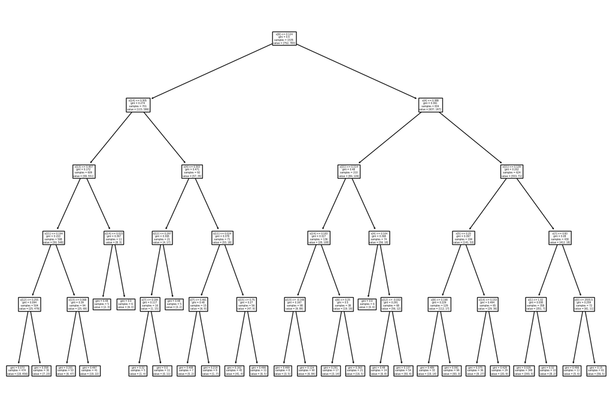

```python
from sklearn.tree import plot_tree
plt.figure(figsize=(15,10))
plot_tree(bestModel)
```

```python
model = KNeighborsClassifier()
paramGridNeigbors = {
    'n_neighbors': [1,2,3,4,5,6,7,8,9,10,20,30]
}

bestModel,bestParams = GridSearchBestModel(model,paramGridNeigbors,X,Y)
resultsNiose['KNeighbors'] = ConfusionMatrix(y_out,bestModel.predict(X_new))
```

```python
model = LogisticRegression()
paramGridLogistic = {
    'C': [1,10, 100],
    'solver': ['newton-cg', 'lbfgs', 'liblinear', 'sag', 'saga'],
    'penalty': ['l1', 'l2'],
    'max_iter': [500,1000,2000,2500],
}
bestModel,bestParams = GridSearchBestModel(model,paramGridLogistic,X,Y)
resultsNiose['LogisticRegression'] = ConfusionMatrix(y_out,bestModel.predict(X_new))
```

[output not shown]

[output cut: 488 more lines]

[output not shown]

```python
model = RandomForestClassifier()
paramRandomForst = {
    'n_estimators': [50,100,150,200],
    'max_depth': [1,3,5,6,7,10],

}
bestModel,bestParams = GridSearchBestModel(model,paramRandomForst,X,Y)
resultsNiose['RandomForest'] = ConfusionMatrix(y_out,bestModel.predict(X_new))
```

```python
accuracyList = {'Accuracy without noise' : results,'Noise accuracy' : resultsNiose}
```

```python
accuracyDataFrame = pd.DataFrame(accuracyList)
display(accuracyDataFrame)
```

|  | Accuracy without noise | Noise accuracy |
| --- | --- | --- |
| DecisionTree | 0.932292 | 0.838542 |
| KNeighbors | 0.505208 | 0.505208 |
| LogisticRegression | 0.947917 | 0.875000 |
| RandomForest | 0.955729 | 0.882812 |

```python
numOfTrain = int(newDataFrame.shape[0] * (8/10))
newDataFrame['PurchaseRate'] = newDataFrame['PurchaseRate'].replace('HIGH',1)
newDataFrame['PurchaseRate'] = newDataFrame['PurchaseRate'].replace('LOW',0)
newTrainData = copy.deepcopy(newDataFrame[:numOfTrain])
newTestData = copy.deepcopy(newDataFrame[numOfTrain:])
X = newTrainData.drop(['PurchaseRate','NumPurchases'], axis=1)
Y = newTrainData['PurchaseRate']
X_new = newTestData.drop(['PurchaseRate','NumPurchases'], axis=1)
y_out = newTestData['PurchaseRate']
```

```python
import xgboost as xgb
dataTrain = xgb.DMatrix(X, label=Y)
dataTest = xgb.DMatrix(X_new, label=y_out)
params = {
    "objective": "binary:logistic",
    "eval_metric": "logloss",
    "max_depth": 3
}
model = xgb.train(params, dataTrain)
yPred = model.predict(dataTest)
yPred = (yPred >= 0.5).astype(int)
print('Accuracy : ',ConfusionMatrix(y_out,yPred))
```

```
Accuracy :  0.9453125
```

```python
paramGridXGboost = {
    "objective": ["binary:logistic"],
    "eval_metric": ["logloss"],
    'max_depth': [3, 5, 7],
    'learning_rate': [0.1, 0.01, 0.05],
    'n_estimators': [100, 500, 1000]
}
gridSearch = GridSearchCV(estimator=xgb.XGBClassifier(), param_grid=paramGridXGboost)
gridSearch.fit(X, Y)
y_pred = gridSearch.predict(X_new)
print('Accuracy : ',ConfusionMatrix(y_out, y_pred))
```

```
Accuracy :  0.9557291666666666
```